# task14

Paulius Kostickis

Thursday, May 05, 2016

1. For the wmurders data:
1. if necessary, find a suitable Box-Cox transformation for the data;

wmurders duomenys - nužudyta moterų iš 100 tūkst., matuota nuo 1950 iki 2004. Kaip matome nėra didelių svyravimų, todėl nebūtina transformuoti.

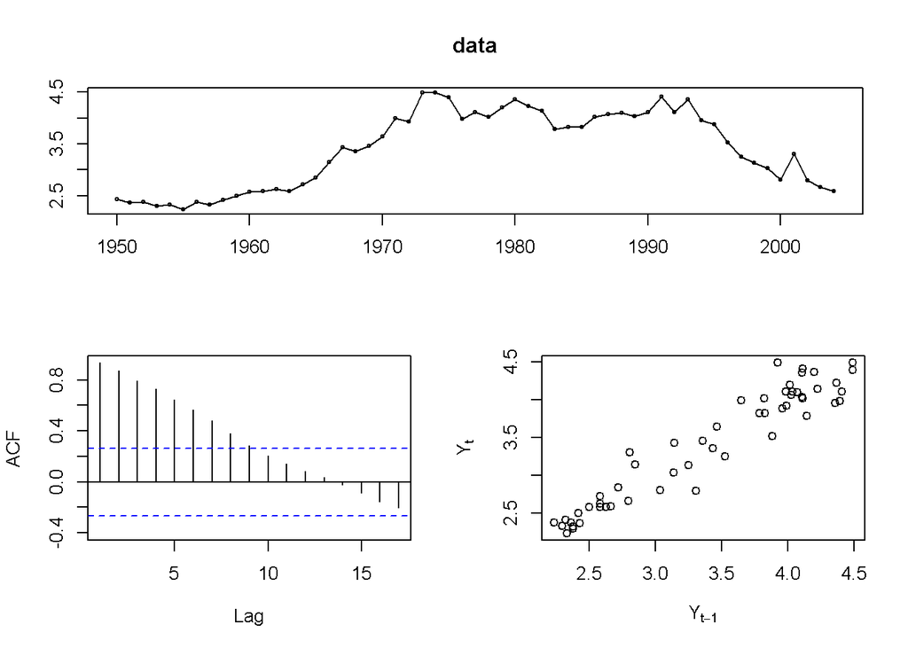

```r
data=wmurders
tsdisplay(data, plot.type="scatter")
```

2. fit a suitable ARIMA model to the transformed data using auto.arima();

#### Auto.arima taikoma duomenim:

```r
mod1=auto.arima(data)
mod1
```

```
## Series: data
## ARIMA(1,2,1)
##
## Coefficients:
##           ar1      ma1
##       -0.2434  -0.8261
## s.e.   0.1553   0.1143
##
## sigma^2 estimated as 0.04457:  log likelihood=6.44
## AIC=-6.88   AICc=-6.39   BIC=-0.97
```

Gauname ARIMA(1,2,1)

3. try some other plausible models by experimenting with the orders chosen;

#### Sužinosime kiek reikia diferencijuoti, kad būtų stacionarūs duomenys (iš auto.arima matome, kad d=2, tiek pat kartų diferencijuoti nurodo ir “ndiffs” funkcija)

```r
nd=ndiffs(data)
nd
```

```
## [1] 2
```

```r
diffdata <- diff(data,differences=nd)
```

Diferencijuotų duomenų ACF atrodo lyg sinusoidinis. O PACF grafike matomas 5-tas reikšmingas lag’as, o tolesni lag’ai nereikšmingi.

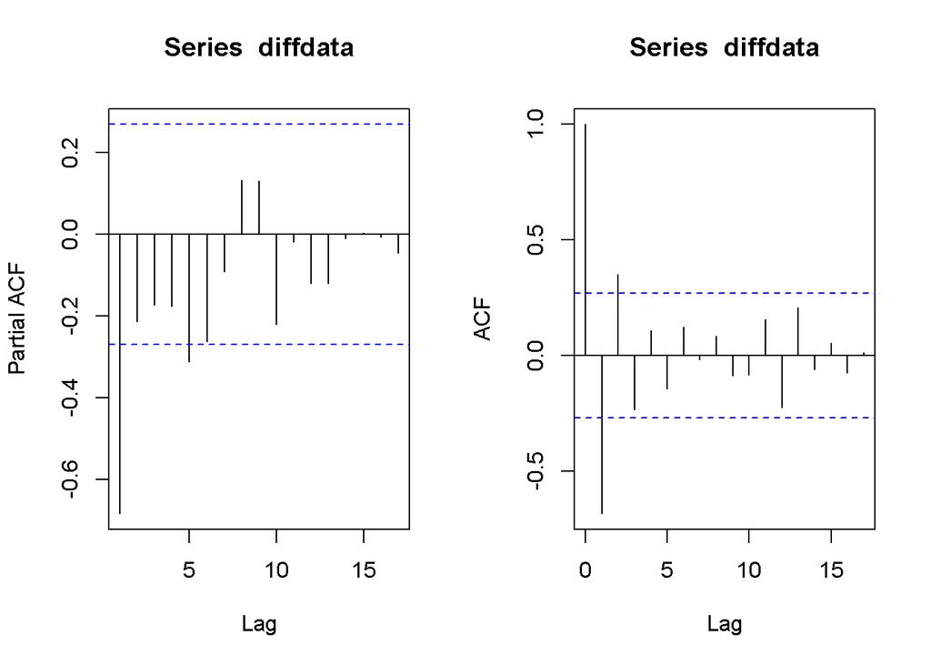

```r
par(mfrow=c(1,2))
pacf(diffdata)
acf(diffdata)
```

#### Reiškia galime spėti, jog p=5, o q=0.

Tai ir naudosime ARIMA modelyje:

```r
mod2=arima(data,c(5,2,0))
```

#### Pakeisime kai kuriuos rodiklius:

```r
mod3=arima(data,c(5,2,1))
mod4=arima(data,c(4,2,0))
```

4. choose what you think is the best model and check the residual diagnostics;

```r
kable(accuracy(mod1))
```

|  | ME | RMSE | MAE | MPE | MAPE | MASE | ACF1 |
| --- | --- | --- | --- | --- | --- | --- | --- |
| Training set | -0.0106596 | 0.2072523 | 0.1528734 | -0.2149476 | 4.335214 | 0.9400996 | 0.0217634 |

```r
kable(accuracy(mod2))
```

|  | ME | RMSE | MAE | MPE | MAPE | MASE | ACF1 |
| --- | --- | --- | --- | --- | --- | --- | --- |
| Training set | -0.004649 | 0.201606 | 0.14575 | -0.0422246 | 4.151886 | 0.8962943 | -0.1006234 |

```r
kable(accuracy(mod3))
```

|  | ME | RMSE | MAE | MPE | MAPE | MASE | ACF1 |
| --- | --- | --- | --- | --- | --- | --- | --- |
| Training set | -0.0072358 | 0.1963481 | 0.1416591 | -0.091171 | 4.053833 | 0.8711367 | -0.0370633 |

```r
kable(accuracy(mod4))
```

|  | ME | RMSE | MAE | MPE | MAPE | MASE | ACF1 |
| --- | --- | --- | --- | --- | --- | --- | --- |
| Training set | -0.002855 | 0.2150796 | 0.1660343 | -0.0180754 | 4.733132 | 1.021033 | -0.0726219 |

```r
mod1$aic
```

```
## [1] -6.879768
```

```r
mod2$aic
```

```
## [1] -3.772489
```

```r
mod3$aic
```

```
## [1] -4.31676
```

```r
mod4$aic
```

```
## [1] 0.4007745
```

#### Ar liekanos baltasis triukšmas?

```r
Box.test(mod3$res, type="Lj")   # p > 0.05, H0 neatmetamas, kad liekanos nekoreliuotos
```

```
##
##  Box-Ljung test
##
## data:  mod3$res
## X-squared = 0.0798, df = 1, p-value = 0.7776
```

```r
mean(mod3$res)                  # vidurkis labai arti 0
```

```
## [1] -0.007235762
```

```r
shapiro.test(mod3$res)          # galime neatmesti H0, nes p > 0.05, liekanos normaliojo skirstinio
```

```
##
##  Shapiro-Wilk normality test
##
## data:  mod3$res
## W = 0.9594, p-value = 0.0604
```

Atlikę testus, galime teigti, jog liekanos baltasis triukšmas

5. produce forecasts of your fitted model. Do the forecasts look reasonable? Prognozė:

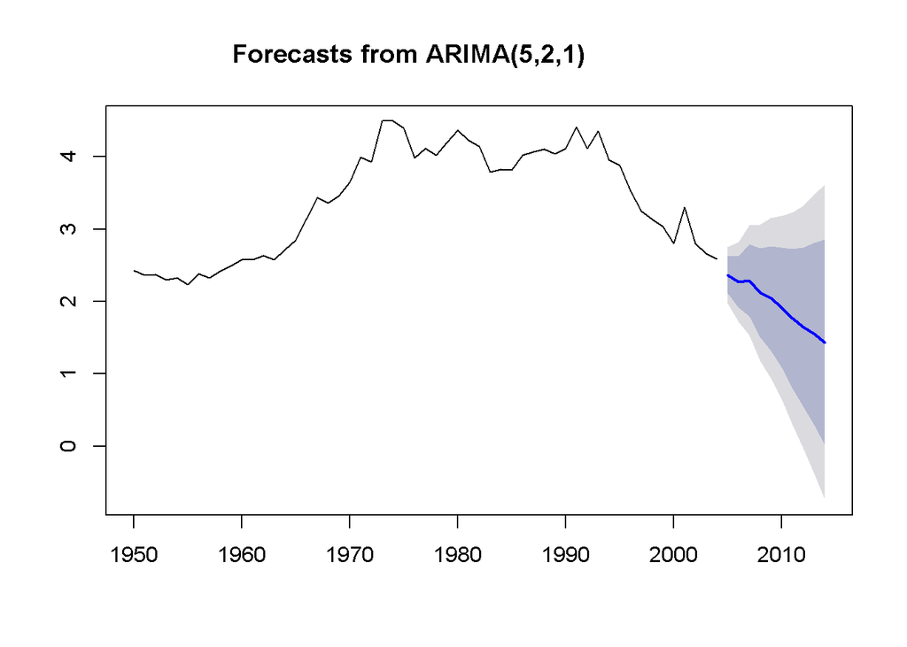

```r
plot(forecast(mod3))
```

Prognozės mažėjimas atrodo logiškas, tačiau galime manyti, kad mažėjimas bus eksponentinis, ne toks status. Priežastys dėl gerėjančios gyvenimo kokybės, nusikalstamumo mažėjimo, didesnio moterų teisių gynimo. Duomenys turėtų artėti link kažkokio skaičiaus, tačiau nekonverguoti į visišką nulį ir neturėtų virsti neigiama reikšme.

6. compare the results with what you would obtain using ets() (with no transformation).

ETS modelis pagal ETS, liekanos pagal testus yra baltasis triukšmas

```r
modETS=ets(wmurders)
modETS
```

```
## ETS(M,N,N)
##
## Call:
##  ets(y = wmurders)
##
##   Smoothing parameters:
##     alpha = 0.9599
##
##   Initial states:
##     l = 2.4177
##
##   sigma:  0.0605
##
##      AIC     AICc      BIC
## 47.36113 47.59190 51.37579
```

```r
Box.test(modETS$res, type="Lj")   # p > 0.05, H0 neatmetamas, kad liekanos nekoreliuotos
```

```
##
##  Box-Ljung test
##
## data:  modETS$res
## X-squared = 0.0831, df = 1, p-value = 0.7732
```

```r
mean(modETS$res)                  # vidurkis labai arti 0
```

```
## [1] 0.00306423
```

```r
shapiro.test(modETS$res)          # galime neatmesti H0, nes p > 0.05, liekanos normaliojo skirstinio
```

```
##
##  Shapiro-Wilk normality test
##
## data:  modETS$res
## W = 0.9841, p-value = 0.6788
```

#### ETS(M,N,N) vs ARIMA(5,2,1)

```r
kable(accuracy(modETS))
```

|  | ME | RMSE | MAE | MPE | MAPE | MASE | ACF1 |
| --- | --- | --- | --- | --- | --- | --- | --- |
| Training set | 0.0033123 | 0.2112237 | 0.1601015 | -0.0556625 | 4.653734 | 0.9845492 | -0.0339494 |

```r
kable(accuracy(mod3))
```

|  | ME | RMSE | MAE | MPE | MAPE | MASE | ACF1 |
| --- | --- | --- | --- | --- | --- | --- | --- |
| Training set | -0.0072358 | 0.1963481 | 0.1416591 | -0.091171 | 4.053833 | 0.8711367 | -0.0370633 |

Matome, jog ARIMA(5,2,1) geresnis pagal accuracy rodiklius.

2. For the usgdp data:

usgdp - tai JAV ketvirčio BVP nuo 1947 iki 2006 metų.

1. if necessary, find a suitable Box-Cox transformation for the data;

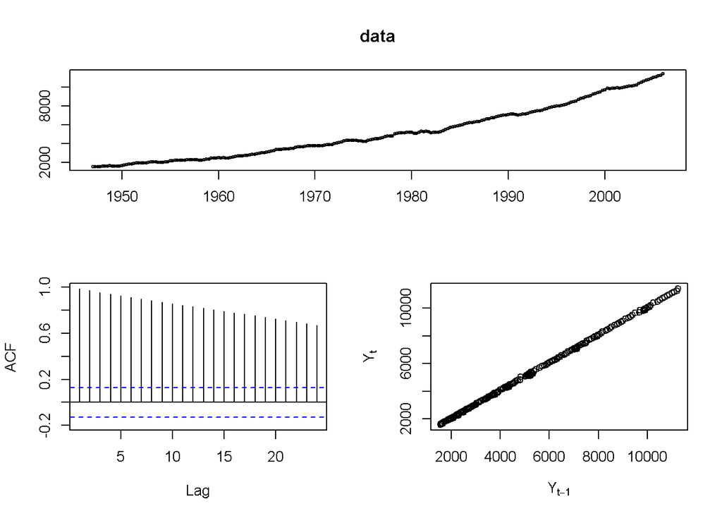

```r
data=usgdp
tsdisplay(data, plot.type="scatter")
```

Kaip matome, duomenys neturi ryškesnių svyravimų, todėl nenaudosime Box-Cox transformacijos.

2. fit a suitable ARIMA model to the transformed data using auto.arima(); ####Randame ARIMA modelį su auto.arima funkcija:

```r
mod1=auto.arima(data)
mod1
```

```
## Series: data
## ARIMA(2,2,2)
##
## Coefficients:
##           ar1     ar2      ma1      ma2
##       -0.1228  0.3106  -0.5835  -0.3669
## s.e.   0.2869  0.0872   0.3004   0.2862
##
## sigma^2 estimated as 1577:  log likelihood=-1199.57
## AIC=2409.13   AICc=2409.39   BIC=2426.43
```

Gauname ARIMA(2,2,2)

3. try some other plausible models by experimenting with the orders chosen;

#### Sužinosime kiek reikia diferencijuoti, kad būtų stacionarūs duomenys (iš auto.arima matome, kad d=2, tiek pat kartų diferencijuoti nurodo ir “ndiffs” funkcija)

```r
nd=ndiffs(data)
nd
```

```
## [1] 2
```

```r
diffdata <- diff(data,differences=nd)
```

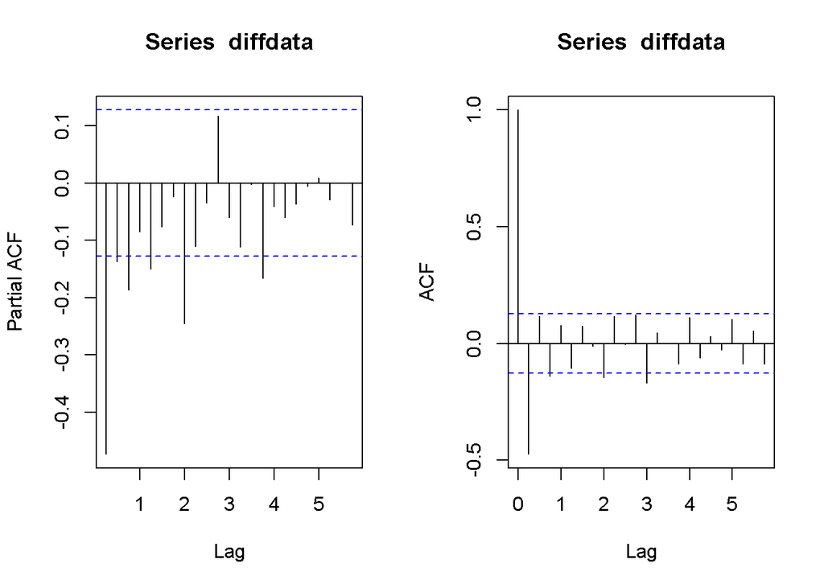

```r
par(mfrow=c(1,2))
pacf(diffdata)
acf(diffdata)
```

```r
mod2=arima(data,c(14,2,0))
```

#### Pakeisime kai kuriuos rodiklius:

```r
mod3=arima(data,c(13,2,0))
mod4=arima(data,c(15,2,0))
mod5=arima(data,c(14,2,1))
mod6=arima(data,c(15,2,1))
mod7=arima(data,c(15,2,2))
```

```r
kable(accuracy(mod1))
```

|  | ME | RMSE | MAE | MPE | MAPE | MASE | ACF1 |
| --- | --- | --- | --- | --- | --- | --- | --- |
| Training set | 4.40617 | 39.54446 | 29.69209 | 0.0914346 | 0.6916719 | 0.1678117 | -0.0178449 |

```r
kable(accuracy(mod2))
```

|  | ME | RMSE | MAE | MPE | MAPE | MASE | ACF1 |
| --- | --- | --- | --- | --- | --- | --- | --- |
| Training set | 1.727259 | 38.91815 | 30.06857 | 0.0424384 | 0.7039524 | 0.6027455 | -0.0066181 |

```r
kable(accuracy(mod3))
```

|  | ME | RMSE | MAE | MPE | MAPE | MASE | ACF1 |
| --- | --- | --- | --- | --- | --- | --- | --- |
| Training set | 1.712715 | 38.92131 | 30.07689 | 0.0421213 | 0.7041166 | 0.6029123 | -0.0060473 |

```r
kable(accuracy(mod4))
```

|  | ME | RMSE | MAE | MPE | MAPE | MASE | ACF1 |
| --- | --- | --- | --- | --- | --- | --- | --- |
| Training set | 1.940859 | 38.25796 | 29.73191 | 0.0468892 | 0.6951764 | 0.5959968 | -0.0156669 |

```r
kable(accuracy(mod5))
```

|  | ME | RMSE | MAE | MPE | MAPE | MASE | ACF1 |
| --- | --- | --- | --- | --- | --- | --- | --- |
| Training set | 4.398347 | 37.69131 | 28.88897 | 0.0922802 | 0.6803453 | 0.5790995 | -0.0139955 |

```r
kable(accuracy(mod6))
```

|  | ME | RMSE | MAE | MPE | MAPE | MASE | ACF1 |
| --- | --- | --- | --- | --- | --- | --- | --- |
| Training set | 4.340751 | 37.49071 | 28.95776 | 0.0919268 | 0.6801512 | 0.5804785 | -0.0079078 |

```r
kable(accuracy(mod7))
```

|  | ME | RMSE | MAE | MPE | MAPE | MASE | ACF1 |
| --- | --- | --- | --- | --- | --- | --- | --- |
| Training set | 4.357849 | 37.38175 | 29.00932 | 0.0920783 | 0.6803192 | 0.5815121 | -0.0143719 |

```r
mod1$aic
```

```
## [1] 2409.132
```

```r
mod2$aic
```

```
## [1] 2421.435
```

```r
mod3$aic
```

```
## [1] 2419.47
```

```r
mod4$aic
```

```
## [1] 2415.894
```

```r
mod5$aic
```

```
## [1] 2409.74
```

```r
mod6$aic
```

```
## [1] 2409.432
```

```r
mod7$aic
```

```
## [1] 2410.133
```

```r
Box.test(mod6$res, type="Lj")   # p > 0.05, H0 neatmetamas, kad liekanos nekoreliuotos
```

```
##
##  Box-Ljung test
##
## data:  mod6$res
## X-squared = 0.015, df = 1, p-value = 0.9025
```

```r
mean(mod6$res)                  # vidurkis nėra arti 0
```

```
## [1] 4.340751
```

```r
shapiro.test(mod6$res)          # galime neatmesti H0, nes p > 0.05, liekanos normaliojo skirstinio
```

```
##
##  Shapiro-Wilk normality test
##
## data:  mod6$res
## W = 0.99, p-value = 0.1012
```

Paklaidų vidurkis skaitiškai nėra arti 0, todėl papildomai atliksiu T testą vidurkiui = 0, nes baltas triukšmas turi turėti vidurkį lygiam 0.

```r
t.test(mod6$res,mu=0)           # p > 0.05, H0 neatmetamas, liekanų vidurkis statistiškai nereikšmingai skiriasi nuo 0.
```

```
##
##  One Sample t-test
##
## data:  mod6$res
## t = 1.7907, df = 236, p-value = 0.07462
## alternative hypothesis: true mean is not equal to 0
## 95 percent confidence interval:
##  -0.4347394  9.1162411
## sample estimates:
## mean of x
##  4.340751
```

5. produce forecasts of your fitted model. Do the forecasts look reasonable?

#### ARIMA(15,2,1) prognozė:

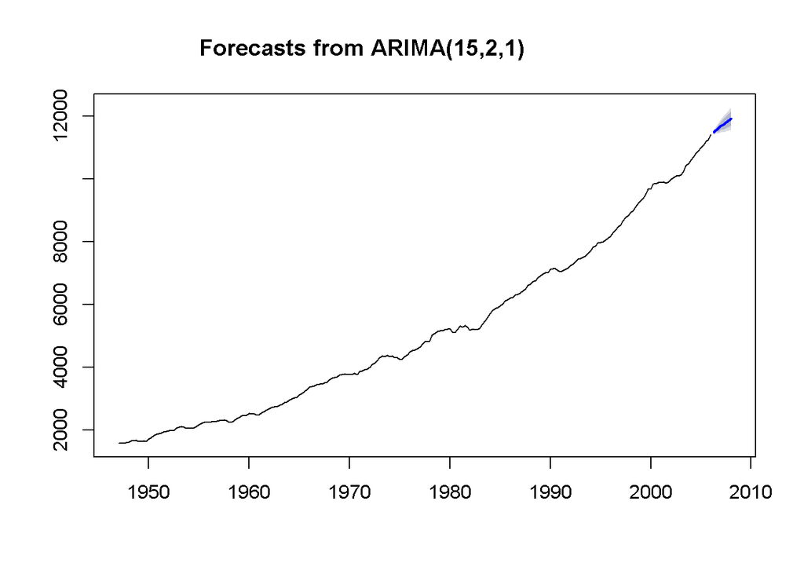

```r
plot(forecast(mod6))
```

Ji atrodo logiška, iš tokių duomenų panašios prognozės ir reikėtų tikėtis.

6. compare the results with what you would obtain using ets() (with no transformation).

#### ETS modelis pagal ETS, liekanos atrodo pagal testus yra baltasis triukšmas

```r
modETS=ets(usgdp)
modETS
```

```
## ETS(A,A,N)
##
## Call:
##  ets(y = usgdp)
##
##   Smoothing parameters:
##     alpha = 0.9999
##     beta  = 0.2775
##
##   Initial states:
##     l = 1559.726
##     b = 10.7507
##
##   sigma:  41.5259
##
##      AIC     AICc      BIC
## 3070.204 3070.377 3084.077
```

```r
Box.test(modETS$res, type="Lj")   # p > 0.05, H0 neatmetamas, kad liekanos nekoreliuotos
```

```
##
##  Box-Ljung test
##
## data:  modETS$res
## X-squared = 1.3865, df = 1, p-value = 0.239
```

```r
mean(modETS$res)                  # vidurkis manoma statistiškai nereikšmingai skiriasi nuo 0
```

```
## [1] 1.424398
```

```r
shapiro.test(modETS$res)          # galime neatmesti H0, nes p > 0.05, liekanos normaliojo skirstinio
```

```
##
##  Shapiro-Wilk normality test
##
## data:  modETS$res
## W = 0.9889, p-value = 0.06595
```

#### ETS(A,A,N) vs ARIMA(15,2,1)

```r
kable(accuracy(modETS))
```

|  | ME | RMSE | MAE | MPE | MAPE | MASE | ACF1 |
| --- | --- | --- | --- | --- | --- | --- | --- |
| Training set | 1.424398 | 41.52588 | 31.80149 | 0.0307896 | 0.7510978 | 0.1797335 | 0.0760054 |

```r
kable(accuracy(mod6))
```

|  | ME | RMSE | MAE | MPE | MAPE | MASE | ACF1 |
| --- | --- | --- | --- | --- | --- | --- | --- |
| Training set | 4.340751 | 37.49071 | 28.95776 | 0.0919268 | 0.6801512 | 0.5804785 | -0.0079078 |

```r
modETS$aic
```

```
## [1] 3070.204
```

```r
mod6$aic
```

```
## [1] 2409.432
```

Matome, jog ARIMA(15,2,1) geresnis pagal accuracy ir AIC rodiklius.

3. For the mcopper data:

mcopper - mėnesinės vario kainos.

1. if necessary, find a suitable Box-Cox transformation for the data;

Iš duomenų grafiko matome, kad galbūt reikėtų ransformuoti duomenis, nes pastebimi svyravimai.

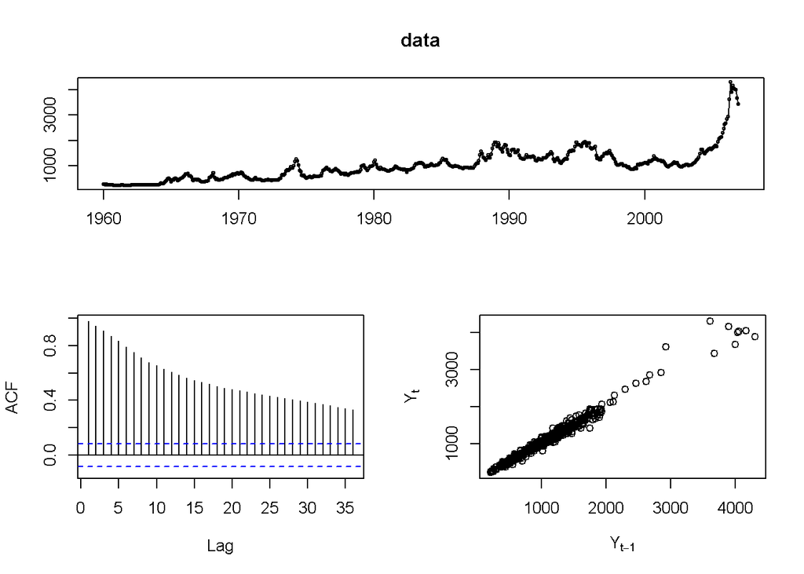

```r
data=mcopper
tsdisplay(data, plot.type="scatter")
```

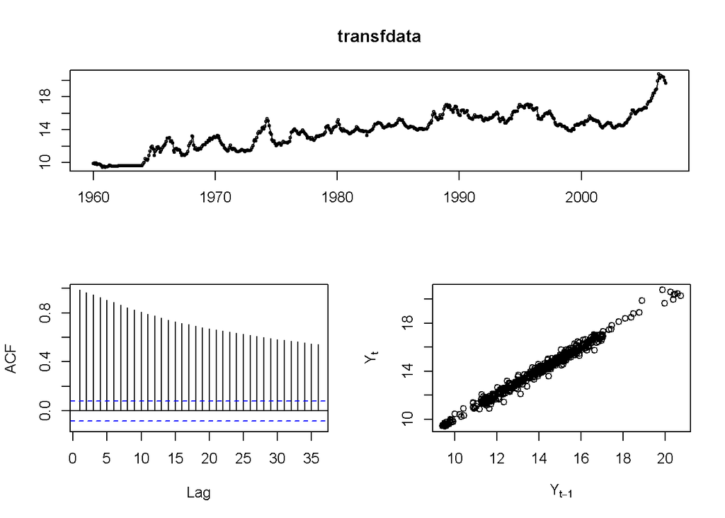

```r
lambda<-BoxCox.lambda(data)               #lambda skaičius randamas
transfdata<-BoxCox(mcopper, lambda=lambda)  #transformuojami duomenys
tsdisplay(transfdata, plot.type="scatter")  #transformuojamų duomenų grafikas
```

Tačiau transformacija akivaizdžiai nesumažino svyravimo. Reiškia nebūtina transformuoti.

2. fit a suitable ARIMA model to the transformed data using auto.arima(); Randame ARIMA modelį su auto.arima funkcija diferencijuotiems duomenim:

```r
mod1=auto.arima(data)
mod1
```

```
## Series: data
## ARIMA(0,1,1)
##
## Coefficients:
##          ma1
##       0.2900
## s.e.  0.0419
##
## sigma^2 estimated as 6015:  log likelihood=-3248.53
## AIC=6501.07   AICc=6501.09   BIC=6509.73
```

Gauname ARIMA(0,1,1)

3. try some other plausible models by experimenting with the orders chosen;

#### Sužinosime kiek reikia diferencijuoti, kad būtų stacionarūs duomenys (iš auto.arima matome, kad d=1, tiek pat kartų diferencijuoti nurodo ir “ndiffs” funkcija)

```r
nd=ndiffs(data)
nd
```

```
## [1] 1
```

```r
diffdata <- diff(transfdata,differences=nd)
```

#### Iš diferencijuotų duomenų ACF ir PACF grafikų neįžvelgiu indikacijų dėl parametrų.

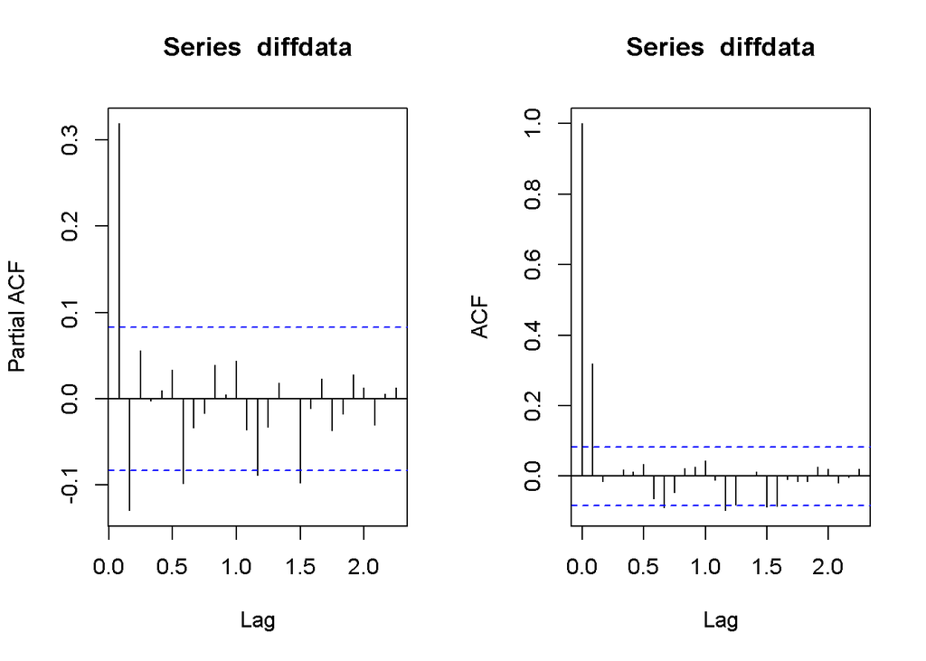

```r
par(mfrow=c(1,2))
pacf(diffdata)
acf(diffdata)
```

#### Tai bandysiu modifikuoti ARIMA(0,1,1) modelį:

```r
mod2=arima(data,c(0,1,2))
mod3=arima(data,c(0,1,3))
mod4=arima(data,c(1,1,3))
mod5=arima(data,c(2,1,3))
```

4. choose what you think is the best model and check the residual diagnostics;

#### Pagal AIC ir accuracy, manyčiau, kad mod1 t.y. ARIMA(0,1,1) yra geriausias:

```r
kable(accuracy(mod1))
```

|  | ME | RMSE | MAE | MPE | MAPE | MASE | ACF1 |
| --- | --- | --- | --- | --- | --- | --- | --- |
| Training set | 4.311873 | 77.48906 | 45.13189 | 0.2257031 | 4.309241 | 0.203058 | -0.0056165 |

```r
kable(accuracy(mod2))
```

|  | ME | RMSE | MAE | MPE | MAPE | MASE | ACF1 |
| --- | --- | --- | --- | --- | --- | --- | --- |
| Training set | 4.361081 | 77.4847 | 45.16893 | 0.2268502 | 4.308834 | 0.9329752 | -0.0037296 |

```r
kable(accuracy(mod3))
```

|  | ME | RMSE | MAE | MPE | MAPE | MASE | ACF1 |
| --- | --- | --- | --- | --- | --- | --- | --- |
| Training set | 4.037085 | 77.29274 | 45.21642 | 0.2188631 | 4.308068 | 0.9339562 | -0.00567 |

```r
kable(accuracy(mod4))
```

|  | ME | RMSE | MAE | MPE | MAPE | MASE | ACF1 |
| --- | --- | --- | --- | --- | --- | --- | --- |
| Training set | 4.031946 | 77.09321 | 45.32127 | 0.2178872 | 4.336802 | 0.9361219 | -0.0041168 |

```r
kable(accuracy(mod5))
```

|  | ME | RMSE | MAE | MPE | MAPE | MASE | ACF1 |
| --- | --- | --- | --- | --- | --- | --- | --- |
| Training set | 3.759704 | 77.09489 | 45.37219 | 0.2117403 | 4.338031 | 0.9371737 | -0.0014969 |

```r
mod1$aic
```

```
## [1] 6501.066
```

```r
mod2$aic
```

```
## [1] 6503.004
```

```r
mod3$aic
```

```
## [1] 6502.231
```

```r
mod4$aic
```

```
## [1] 6501.353
```

```r
mod5$aic
```

```
## [1] 6503.375
```

#### Ar geriausio modelio liekanos yra baltasis triukšmas:

```r
Box.test(mod1$res, type="Lj")
```

```
##
##  Box-Ljung test
##
## data:  mod1$res
## X-squared = 0.0179, df = 1, p-value = 0.8936
```

```r
shapiro.test(mod1$res)          # galime atmesti H0, nes p < 0.05, liekanos  nėra normaliojo skirstinio
```

```
##
##  Shapiro-Wilk normality test
##
## data:  mod1$res
## W = 0.7951, p-value < 2.2e-16
```

Paklaidos nėra baltasis triukšmas, nes neturi normaliojo skirstinio. Tačiau modifikuotų modelio toks pat rezultatas, tai nekeisiu savo pasirinkto modelio, tačiau reiškia, kad prognozė gali būti geresnė.

5. produce forecasts of your fitted model. Do the forecasts look reasonable? ####Geriausio modelio ARIMA(0,1,1) prognozė

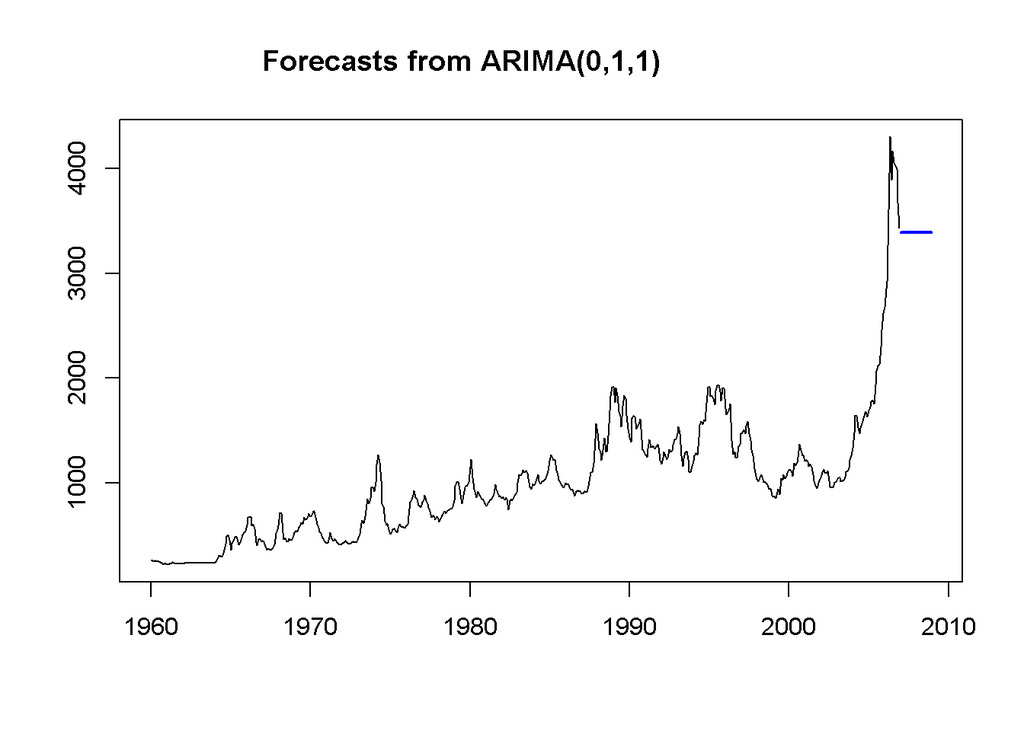

```r
plot(forecast(mod1),plot.conf=F)
```

Iš tikro, turint tokius duomenis, mes nelabai galime prognozuoti vario kainos. Mažai tikėtina, kad ši prognozė yra gera, tačiau turint tik tokius duomenis galime manyti, jog geresnio modelio negaliu sukurti. Galima būtų manyti, kad vario kainos **pokytis** mažai priklauso nuo savo praeities kainos, o daugiau priklauso nuo kitų rinkos kintamųjų.

6. compare the results with what you would obtain using ets() (with no transformation).

#### ETS modelis:

```r
modETS=ets(data)
modETS
```

```
## ETS(M,Ad,N)
##
## Call:
##  ets(y = data)
##
##   Smoothing parameters:
##     alpha = 0.9999
##     beta  = 0.2175
##     phi   = 0.8
##
##   Initial states:
##     l = 264.8936
##     b = -3.4118
##
##   sigma:  0.0629
##
##      AIC     AICc      BIC
## 8050.042 8050.149 8071.717
```

```r
Box.test(modETS$res, type="Lj")   # p < 0.05, H0 atmetamas, liekanos koreliuotos
```

```
##
##  Box-Ljung test
##
## data:  modETS$res
## X-squared = 15.8829, df = 1, p-value = 6.738e-05
```

Gauname ETS(M,Ad,N)

#### ETS(M,Ad,N) vs ARIMA(0,1,1)

```r
kable(accuracy(modETS))
```

|  | ME | RMSE | MAE | MPE | MAPE | MASE | ACF1 |
| --- | --- | --- | --- | --- | --- | --- | --- |
| Training set | 2.663937 | 78.87828 | 46.74887 | 0.1870949 | 4.502486 | 0.2103332 | 0.1030061 |

```r
kable(accuracy(mod1))
```

|  | ME | RMSE | MAE | MPE | MAPE | MASE | ACF1 |
| --- | --- | --- | --- | --- | --- | --- | --- |
| Training set | 4.311873 | 77.48906 | 45.13189 | 0.2257031 | 4.309241 | 0.203058 | -0.0056165 |

```r
modETS$aic
```

```
## [1] 8050.042
```

```r
mod1$aic
```

```
## [1] 6501.066
```

Pagal AIC ir accuracy rodiklius ARIMA(0,1,1) geresnis.